# Stochastic Calculus II

Alexander Kaier, Christoph Richard

2025-11-06

# 1 Continuous random variables

So far, we have considered discrete random variables, which might only attain a countable number of different values with positive probabilities. However, it is often not convenient to describe an experiment using discrete random variables. Consider for example measuring human body heights. If you measure height in a certain unit such as mm, you deal with a discrete quantity. But if you could measure accurately enough, every person might have its own unique height, and then there would be as many different heights as there are people on earth.

**We might thus assign a probability of 0 to the event that any specific value will be observed in reality. This can not be described by a discrete random variable. We can, however, prescribe the probability of observing values within a range from** $a$ to $b$. We might then use a suitable non-negative function $f(x)$ to define $\mathbb{P}[X\in(a,b)]$ by the formula

$$\mathbb{P}[X\in(a,b]] = \int_a^bf(x)dx$$

The probability of $X$ taking values between $a$ and $b$ is thus the area below the curve and the $x$-axis between $a$ and $b$. The function $f$ must certainly integrate to $1$ over the real axis::

$$\begin{align}
\int_{-\infty}^{\infty}f(x)dx &= 1
\end{align}$$

Typical suitable functions, such as all our examples below, are piecewise continuous, i.e., they are composed of finitely many continuous pieces. The function $f$ is called a probability density function (PDF). Corresponding random variables are called continuous, as their cumulative distribution function (CDF), defined by $t\mapsto \mathbb P[X\le t]$, is continuous. In particular, such a CDF has no jumps. This results in $\mathbb P[X=a]=0$ for all $a$, in contrast to the discrete case. Be aware that not every continuous random variable is described by some function $f$.

## 1.1 Expectation

The expectation of a continuous RV is defined analogously to the discrete case, where we can interpret the expectation as a weighted sum of the values the RV can take. For a continuous RV, we have to replace the sum by an integral:

$$\begin{align}
\mathbb{E}[X] &:= \int_{-\infty}^{\infty}xf(x)dx
\end{align}$$

Keep in mind that the above expression might not exist at all. Moreover if it exists, it might not be finite. This is analogous to the discrete case, e.g. the St. Petersburg paradox. The expectation of a RV is also called its *first moment*.

## 1.2 Variance

Assume that a continuous RV has a finite expectation. The variance of that RV is defined in analogy to the discrete case, namely as the expected squared deviation from its expectation:

$$\begin{align}
\mathbb{V}[X] &:= \int_{-\infty}^{\infty}(x-\mathbb{E}[X])^2f(x)dx
\\
&= \mathbb{E}[X^2]-\mathbb{E}[X]^2
\end{align}$$

The second equality means that the variance of a RV with a finite expectation can be described as the difference between its expected square (also called *second moment*) and its squared first moment. In particular, this holds for both discrete RV’s and continuous RV’s, as long as they have a finite expectation.

Expectation and variance are important parameters of any RV, as they quantify in a simple way where to expect typical values of the RV. This is of course less information than knowing the whole distribution of the RV.

# 2 Continuous probability distributions

In a previous section, we have encountered many important discrete probability distributions. In this section, we will introduce some important continuous probability distributions. The usage of a PDF in R is quite similar to the usage of a PMF. The functions are called `d<distribution>` for the PDF, `p<distribution>` for the CDF, `q<distribution>` for the smallest quantile function and `r<distribution>` for the random number generator.

## 2.1 Uniform distribution

The class of uniform distributions is arguably the simplest class of continuous distributions. The uniform distribution $U(a,b)$ is defined on the interval $[a,b]$. We can describe this distribution by the following PDF. We also give the expectation and variance of a random variable $X$ distributed as $U(a,b)$.

$$\begin{align}
f(x) &= \frac{1}{b-a},\quad x\in[a,b] \\
f(x) &= 0,\quad \text{elsewhere} \\
\mathbb{E}[X] &= \frac{a+b}{2} \\
\mathbb{V}[X] &= \frac{(b-a)^2}{12}
\end{align}$$

In R, it looks like follows for different values of $a$ and $b$:

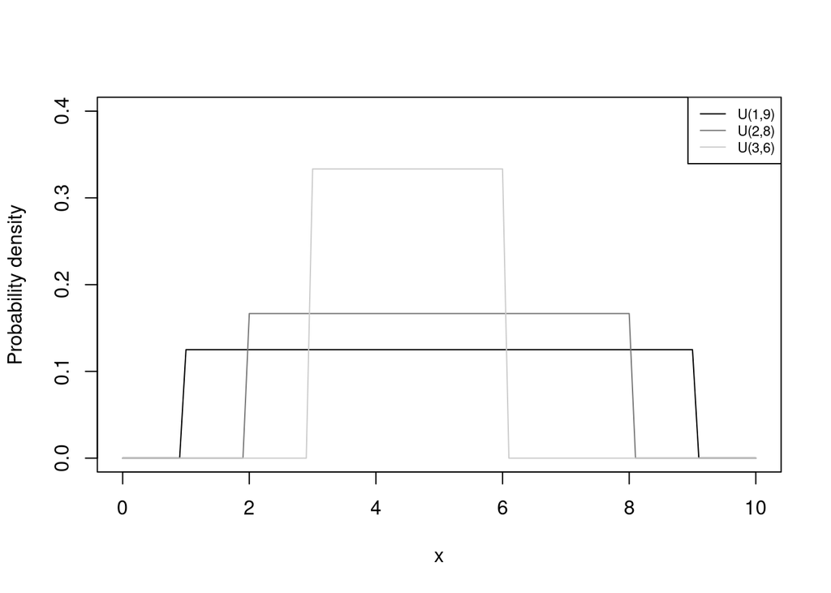

```r
x_values <- seq(0, 10, 0.1)
plot(x_values, dunif(x=x_values, min = 1, max = 9), col='black', type = 'l', ylim = c(0,0.4),
     xlab = "x", ylab = 'Probability density')
lines(x_values, dunif(x=x_values, min = 2, max = 8), col='#777777', lty=1)
lines(x_values, dunif(x=x_values, min = 3, max = 6), col='#CCCCCC', lty=1)
# Add a legend
legend('topright', legend = c("U(1,9)", "U(2,8)", "U(3,6)"),
       col = c("black", "#777777", "#CCCCCC"), lty = 1, cex = 0.7)
```

We use uniform distributions whenever we think that there is “no preferred set of values”. Here are some examples where uniform distributions are used:

- The waiting time for a bus line which passes by every 10 minutes. If we arrive randomly at the bus stop, the time we have to wait until the bus arrives shall be uniformly distributed between 0 and 10 minutes.
- In statistical testing, often the $p$-value $p(x)$ of an observation $x$ is used in order to make the test decision. For continuous test statistics, the $p$-value is a random variable that is designed in a way such that it is $U(0,1)$-distributed given the null hypothesis. This allows for a simple interpretation whether the observation $x$ is typical for the underlying null hypothesis. This approximately applies to optimal local alignments of random protein sequences.

## 2.2 Exponential distribution

We have seen above that the geometric distribution $Geo(p)$ models the number of trials until the $1^{st}$ success. Now, if the probability $p$ of a success is quite low, the geometric distribution can be approximated by an exponential distribution $Exp(\lambda)$ with $\lambda=p$. In general, the parameter $\lambda$ may be any positive real number. The exponential distribution $Exp(\lambda)$ is described by the following PDF, which is nonzero only for positive real values:

$$\begin{align}
f(x) &=
\begin{cases}
\lambda e^{-\lambda x},\quad x\ge 0 \\
0,\quad \text{elsewhere}
\end{cases} \\
\mathbb{E}[X] &= \frac{1}{\lambda} \\
\mathbb{V}[X] &= \frac{1}{\lambda^2}
\end{align}$$

In R, the exponential distribution looks like this:

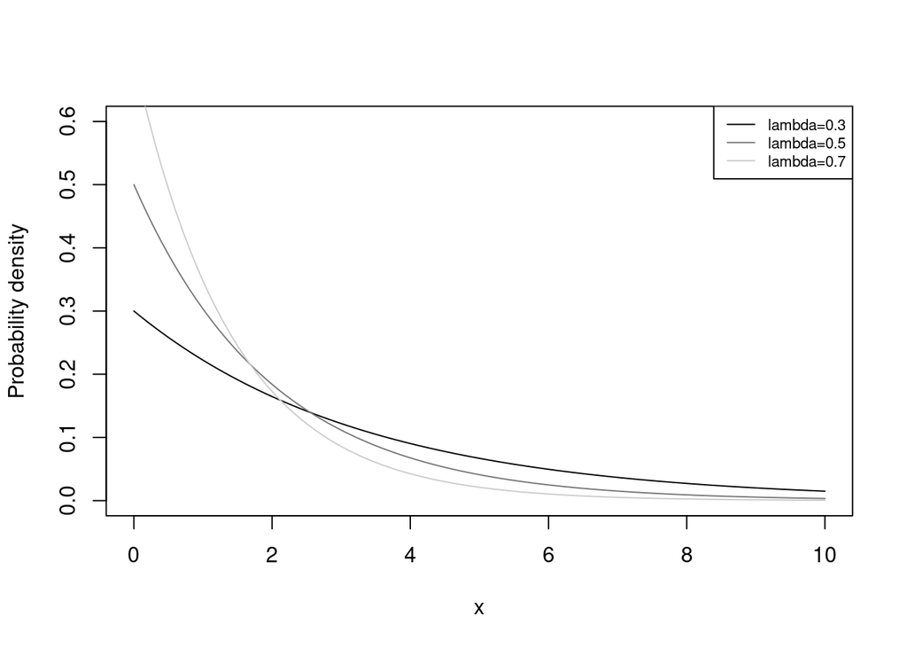

```r
x_values <- seq(0, 10, 0.1)
plot(x_values, dexp(x=x_values, rate = 0.3), col='black', type = 'l', ylim = c(0,0.6),
     xlab = "x", ylab = 'Probability density')
lines(x_values, dexp(x=x_values, rate = 0.5), col='#777777', lty=1)
lines(x_values, dexp(x=x_values, rate = 0.7), col='#CCCCCC', lty=1)
# Add a legend
legend('topright', legend = c("lambda=0.3", "lambda=0.5", "lambda=0.7"),
       col = c("black", "#777777", "#CCCCCC"), lty = 1, cex = 0.7)
```

The approximation of the geometric distribution in terms of the exponential distribution is shown in the following graphics. Note that we have plotted the cumulative distribution functions for comparison. Another possibility would be plotting a histogram of the geometric distribution together with the PDF of the exponential distribution, compare the Gumbel distribution example below.

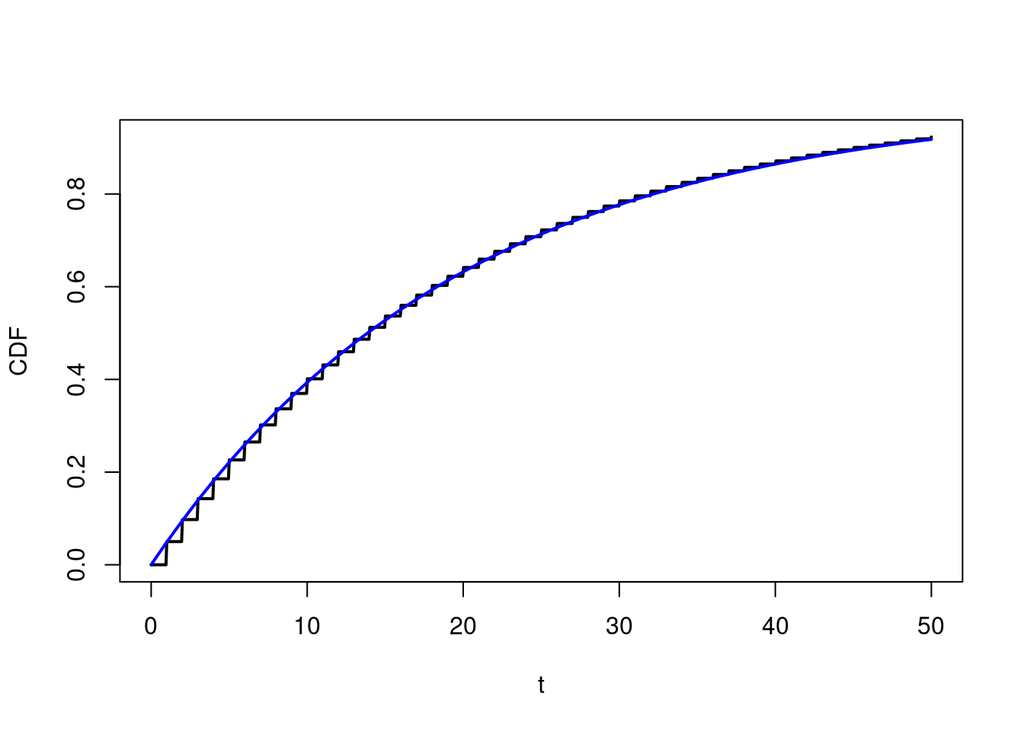

```r
n=10; p=0.05
mypgeom=function(x) pgeom(x-1,p)
plot(mypgeom, xlim=c(0,50), n=1000, col="black",
     lwd=2, ylab="CDF", xlab="t")
curve(pexp(x,p), add=TRUE, col="blue", lwd=2)
```

Depending on the situation, exponential distributions may display some advantages compared to geometric distributions. Exponential distributions can describe rare events in continuous time, as opposed to discrete time for the geometric distributions. A description in continuous time may be reasonable for modeling the following scenarios:

- The waiting time until a radioactive atom decays
- The time until a customer arrives at a store
- The time until a machine breaks down
- The distance between adjacent mutations in a DNA sequence (remember that $p$ might be quite small and therefore, $\mathbb{E}[X]$ is quite large)

You see that the exponential distribution is used often to mode a class of problems where the time until an event happens is of interest.

## 2.3 Erlang distribution

We have just seen that the binomial distribution may be approximated by the Poisson distribution and that the geometric distribution may be approximated by the exponential distribution when the probability of success is quite low. When can also approximate the negative binomial distribution $NB(r,p)$ by the Erlang distribution $Erl(r,\lambda)$, where $p=\lambda$. In this case, we set $\lambda=p$ and $k=r$, where $r\in\mathbb{N}$ and $\lambda \in (0, \infty)$. An Erlang-distributed RV $X$ is an $r$-fold sum of independent $Exp(\lambda)$-distributed RVs. By definition $X$ has expectation $\mathbb{E}[X]=r/\lambda$ and variance $\mathbb{V}[X]=r/\lambda^2$. Since $X$ is a continuous RV, the Erlang distribution $Erlang(k,\lambda)$ is described by the following PDF:

$$f_{r,\lambda}(x) = \frac{\lambda^r}{(r-1)!}x^{r-1}e^{-\lambda x},\quad
x\ge 0.$$
The cumulative distribution function is given by:

$$\mathbb{P}[X\leq t] = e^{-\lambda t} \sum_{k=0}^{r-1} \frac{(\lambda
t)^k}{k!},\quad t\ge 0.$$

The Erlang distribution can be used, for example, to describe the random amount time of time between $r$ consecutive decays in a radioactive source, the time until $r$ customers arrive at a store, the time until a machine breaks down for the $r^{th}$ time or the distance between $r$ mutation on a strand of DNA.

As a matter of fact, for $t\geq0$ and when $r\in\mathbb{R}$, the Erlang distribution can be described by the Gamma distribution $Gamma(r,\lambda)$, which has the following CDF.

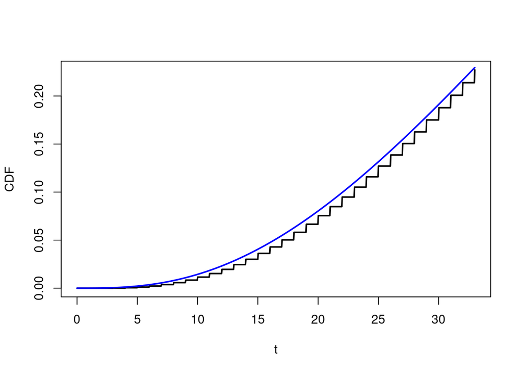

```r
n <- 33; p <- 0.05; r <- 3
mypbinom <- function(x) pnbinom(x-r, size = r, prob = p)
plot(mypbinom, xlim=c(0,n), n=1000, col="black", lwd=2, ylab="CDF", xlab="t")
curve(pgamma(x,shape=r, scale=1/p), add=TRUE, col="blue", lwd=2)
```

## 2.4 Normal distribution

The class of normal distributions $N(\mu,\sigma^2)$ is arguably the most important class of distributions in statistics. It is defined by two real numbers: their expectation $\mu$ and their variance $\sigma^2$. The normal distribution $N(\mu,\sigma^2)$ is, for $\mu$ any real number and $\sigma^2$ any positive real number, described by the following PDF:

$$\begin{align}
f(x) &=
\frac{1}{\sqrt{2\pi\sigma^2}}\exp\left(-\frac{(x-\mu)^2}{2\sigma^2}\right)
\\
\mathbb{E}[X] &= \mu \\
\mathbb{V}[X] &= \sigma^2
\end{align}$$

In R, the normal distribution looks like this for different values of $\mu$ and $\sigma^2$. Note that R expects as input the expectation $\mu$ and the standard deviation $\sigma$, not the variance $\sigma^2$!

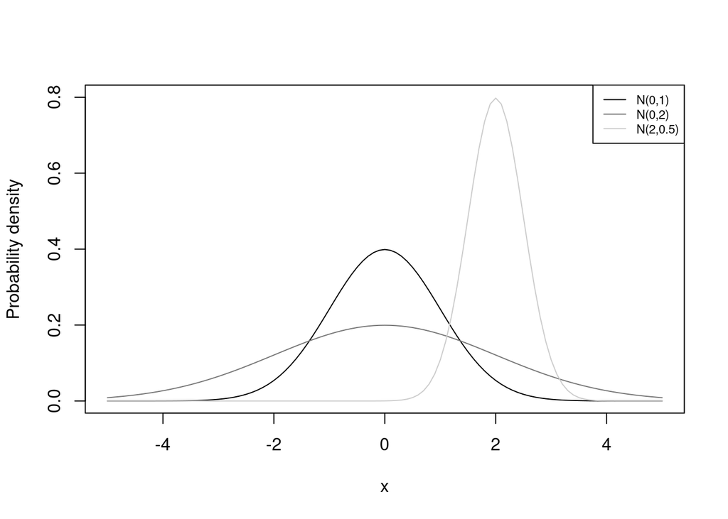

```r
x_values <- seq(-5, 5, 0.1)
plot(x_values, dnorm(x=x_values, mean = 0, sd = 1), col='black', type = 'l', ylim = c(0,0.8),
     xlab = "x", ylab = 'Probability density')
lines(x_values, dnorm(x=x_values, mean = 0, sd = 2), col='#777777', lty=1)
lines(x_values, dnorm(x=x_values, mean = 2, sd = 0.5), col='#CCCCCC', lty=1)
# Add a legend
legend('topright', legend = c("N(0,1)", "N(0,2)", "N(2,0.5)"),
       col = c("black", "#777777", "#CCCCCC"), lty = 1, cex = 0.7)
```

Before we move on to the final distribution, we should stay with the normal distribution a little longer, since it is so important in so many fields, as you see soon.

When $\mu=0$ and $\sigma=1$, the distribution is called *standard normal distribution* and it looks like this:

$$\begin{align}
f(x) &= \frac{1}{\sqrt{2\pi}} exp\left(-\frac{1}{2}x^2\right) \\
\mathbb{E}[X] &= 0 \\
\mathbb{V}[X] &= 1
\end{align}$$

We have argued in the micro-primer on stochastics that any random variable $Y$ distributed as $N(\mu,\sigma^2)$ is related to a standard normally distributed random variable $X$ by the formula $Y=\mu+\sigma X$. You may thus consider the standard normal distribution as the fundamental normal distribution, and all other normal distributions being scaled and translated versions of the standard normal distribution. Often the standard normal distribution is used in order to calculate probabilities for a general normal distribution. The above PDF of the standard normal distribution is often denoted $\phi$ instead of $f$ in the literature.

Finally, as you already saw above for the exponential distribution and the Erlang distribution, ther is the *cumulative distribution function (CDF)* $t\mapsto \mathbb P[X\le t]$ of a random variable $X$. It is often abbreviated by $F_X$. Pay attention to the fact that we use $X$ to indicate that we talk about the CDF of the real random variable $X$ and that we use $t$ to define the value of $F_X$ at position $t$.

We treat the CDF of the standard normal distribution as an example. Since the standard normal distribution is so important, it is often denoted by $\Phi$. An explicit expression of $\Phi$ is not of interest for us right now. It suffices to understand that $\Phi(t)$ is the probability that a random variable $X$ takes a value less than or equal to $t$. Using the PDF of $\Phi$, this can be expressed as

$$\begin{align}
\Phi(t) &= \int_{-\infty}^{t} \phi(x) dx= \int_{-\infty}^{t}
\frac{1}{\sqrt{2\pi}} exp\left(-\frac{1}{2}x^2\right) dx
\end{align}$$

When plotting both the CDF and PDF of the standard normal distribution in R, we get:

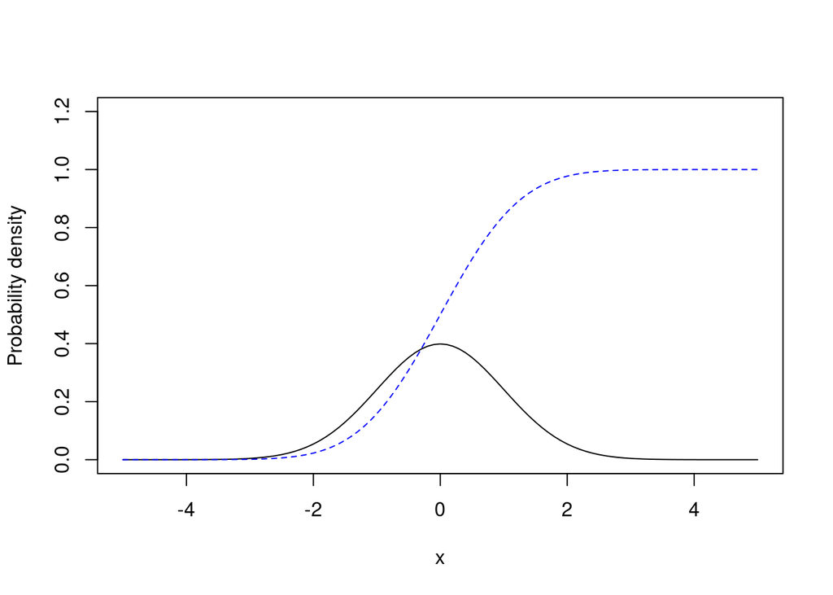

```r
x_values <- seq(-5, 5, 0.1)
plot(x_values, dnorm(x=x_values, mean = 0, sd = 1), col='black', type = 'l', ylim = c(0,1.2),
     xlab = "x", ylab = 'Probability density')
lines(x_values, pnorm(q=x_values, mean = 0, sd = 1), col='blue', lty=2)
```

You can clearly see that the CDF is the integral of the PDF. The CDF is always between 0 and 1 and is a monotonically increasing function (this is true for all probability distributions). The CDF is often used to calculate probabilities for the normal distribution.

Later, we will make heavy use of another CDF, so it is worthwhile to ponder about the value to write expression like $\mathbb{P}[X>k]$ and $\mathbb{P}[X\leq k]$ for a random variable of interest, e.g. the maximum alignment score between two sequences.

## 2.5 Exercises

1. One area of biological research where mathematics and especially stochastics and statistics are of great importance is ecology. Imagine you work in the local bureau that is responsible for environmental protection and are currently working on the effect of invasive species on the ecosystem. The arrival of an invasive species in a new habitat can have devastating effects on the local ecosystem. Former studies have shown that the arrival times of invasive species follow a Poisson process with a rate of $\lambda=0.2/\text{year}$. A local politician is drafting a new law regarding the actions taken against invasive species and needs some information. She asks you to provide her with the average waiting time until a new invasive species arrives, the probability that at least one invasive species arrives in the next year, and the waiting time $t_{95}$ for which you can make the following statement: “I am 95% certain that the time that passes until the arrival of an invasive species is lower than $t_{95}$”. Also, she asks you to simulate to make a nice graph for her to show to the public and colleagues to get support for her draft.

   TIP: The scenario in this question is not unrealistic. Politicians oftentimes need to make decisions based on scientific data. It is important to be able to communicate the results of statistical analyses in a way that is understandable to non-experts. In this exercise, the biggest challenge for you is to extract the important information and questions that need to be answered. Then you need to understand which distribution to use for modelling the waiting time using $\lambda$. After that, everything else is more or less easy.

   1.1. You first need to find a fitting distribution to make a statement about the average waiting time. What scale is the waiting time on? Is it discrete or continuous? What role does $\lambda$ play in the distribution?

   1.2. Once you have the distribution there is nothing you can’t do. What is average waiting time until the arrival of an invasive species.

   1.3. Finding the probability that at least one invasive species arrives in the next year might be a little tricky. Remember that you have multiple function at your disposal to calculate different features of a probability distribution. It may be helpful to draw a picture of the distribution and think about what you need to know to answer the question.

   1.4. The waiting time $t_{95}$ for which you can make the following statement: “I am 95% certain that the time that passes until the arrival of an invasive species is lower than $t_{95}$” This may seem hard at first, but here again, R provides you with just the right function for this. Think about how this question might be related to the last one.

   1.5. Simulate 1,000 waiting times and plot the distribution of waiting times in a histrogram. By know, this is probably a piece of cake for you.

   1.6. Plot the density of a fitting distribution of waiting lines on top of the histogram. This is a little bit more challenging, but you can do it. One of the functions available for distributions can calcualte the probability for any value on the x-axis. The function `curve` will help you plotting the theoretical distribution over the histogram.
2. The mass of the amino acid serine (Ser) is 105 Da. When measuring its mass, we usually observe a small deviation from the true value for different reasons. Let’s assume a device we use for measuring the mass of Ser has such a precision that the measurement is normally distributed with a mean of 105 Da and a standard deviation of 1 Da.

   2.1. Given the information above, what is the probability that the measured mass of a randomly selected unmodified Ser molecule is larger than 106 Da? Chemically modified Ser usually has a mass of more than 106 Da. Would you argue in favor of a modified Ser or not if your observed mass is larger than 106?

   2.2. You are not convinced that the mass of the Ser you measured before, which was over 106 Da, is actually evidence enough for a modified Ser. So you decide to switch to a more precise device. The new device has a standard deviation of 0.2 Da. If you now measure a Ser with more than 106 Da, would you be convinced that the Ser was actually modified or would you attribute the value to the device’s imprecision?

# 3 Point processes

A point process is an increasing sequence $T=(T_i)_{i\in \mathbb N}$ of random variables which we interpret as positions of random points on the real line.

## 3.1 Bernoulli point process

A Bernoulli process can alternatively described as a point process $(T_i)_{i\in \mathbb N}$ where we collect the positions $T_i$ of the $i^{th}$ occurrence of $1$. Then the waiting times $L_i=T_{i+1}-T_i$ between consecutive $1$’s are independent $Geo(p)$ distributed random variables. We call this point process the Bernoulli point process.

In *R*, we may generate a realization of the Bernoulli point process as follows.

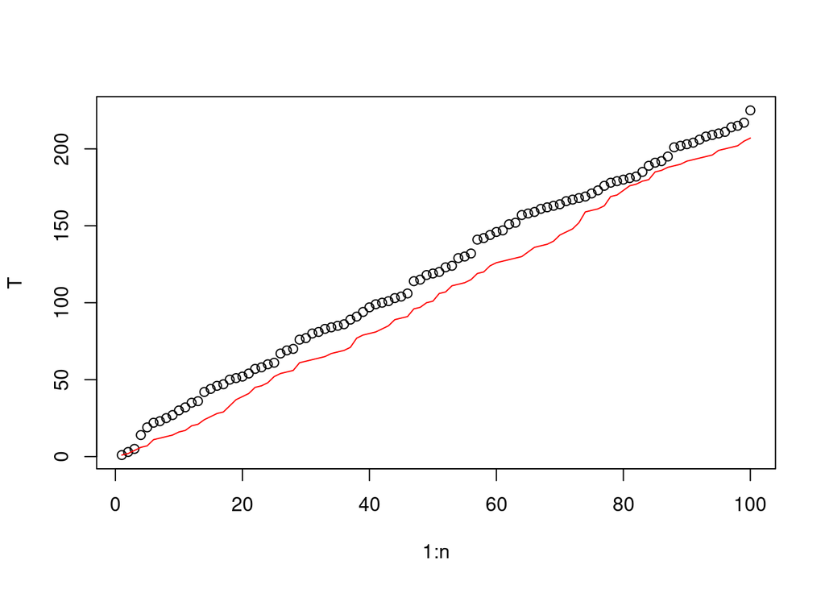

```r
# Bernoulli point process
# generate Geo(p) distributed waiting times L
p=0.5; n=100
G=rgeom(n, prob=p)+1
L=rnbinom(n, prob=p,size=1)+1
# positions of occurence of 1
T=cumsum(G)
plot(1:n,T)
lines(1:n, cumsum(L), col="red")
```

## 3.2 Poisson point process

For a Poisson point process of intensity $\lambda$, the waiting times $L_i= T_{i+1}-T_i$ between two consecutive points are independent $Exp(\lambda)$ distributed random variables.

In *R*, we may generate a realisation of the Poisson point process as follows.

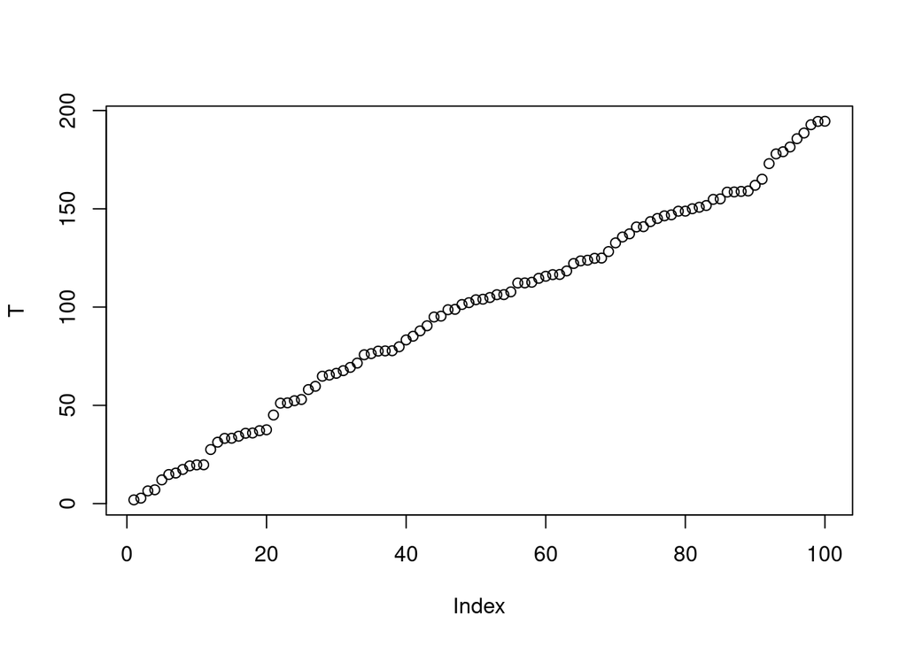

```r
# Poisson point process
# generate Exp(lambda) distributed waiting times L
lam=0.5; n=100
L=rexp(n, rate=lam)
# positions of occurence of points
T=cumsum(L)
plot(T)
```

Thus $T_r$ is a sum of $r$ independent $Exp(\lambda)$ distributed random variables. Thus the distribution of $T_r$ is the Erlang distribution $Erl(r,\lambda)$. This may be checked in R via simulation.

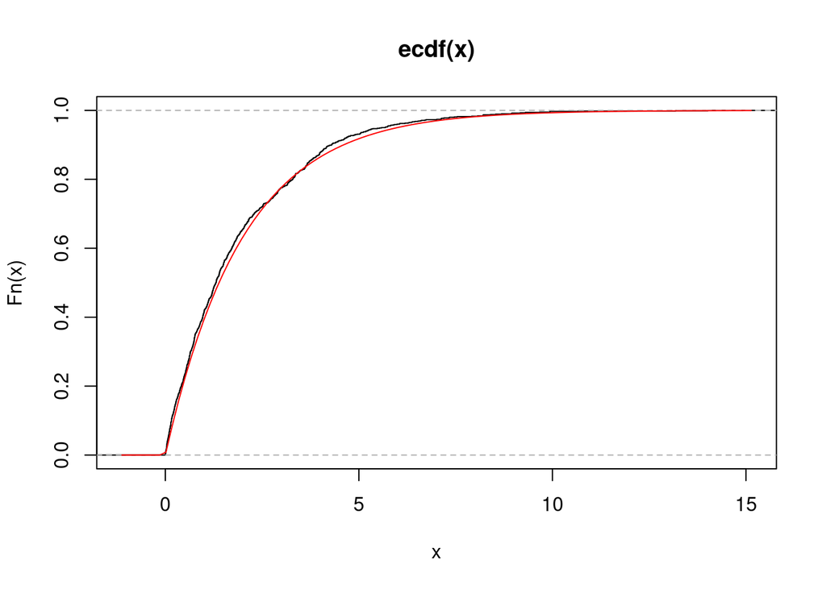

```r
lam=0.5; r=1
N=1000; dist=numeric(N)
for (i in 1:N){
  L=rexp(r, rate=lam)
  Tr=cumsum(L)[r]
  dist[i]=Tr
}
# Plot the ECDF of the distances
plot.ecdf(dist)
# Superimpose the Erl(r,lam) distribution
curve(pgamma(x, rate=lam, shape=r), add=TRUE, col="red")
```

It can be computed that the number of points in an interval $[a,b]$ is distributed as $Poi(\lambda(b-a))$. As the expected number of points in such an interval is $\lambda(b-a)$, this means that the points of a Poisson process have density $\lambda$ almost surely, by the strong law of large numbers.

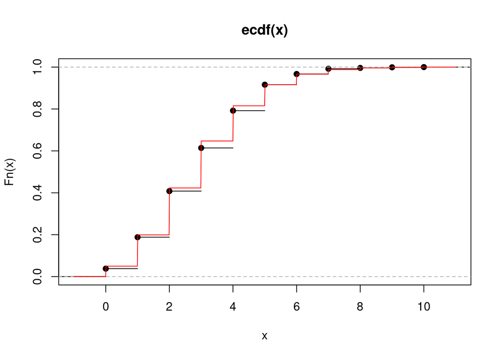

```r
lam=1; a=0; b=3
N=1000; dist=numeric(N)
for (i in 1:N){
  L=rexp(100, rate=lam)
  T=cumsum(L)
  dist[i]=sum(T>=a & T<=b)
}
plot.ecdf(dist)
curve(ppois(x, lam*(b-a) ), add=TRUE, col="red", n=1000)
```

## 3.3 Relation between the two processes

We may view the Poisson point process with parameter $\lambda=p$ as a continuum approximation to the discrete Bernoulli point process with probability $p$. Alternatively, we may view the discrete Bernoulli point process as an approximation to the continuum Poisson point process. The latter viewpoint is helpful for an intuitive understanding of the Poisson point process. The former viewpoint is helpful for deriving simple approximate formulae for Bernoulli point process quantities.

# 4 Sum of random variables

Let $X_1, \ldots, X_n$ be independent identically distributed random variables, which all have finite expectation $\mu$ and finite positive variance $\sigma^2$. When repeating an experiment independently, this will often be a reasonable assumption. One might thus refer to this case as the ``normal’’ case. We would like to study the sum

$$S_n=X_1+\ldots+X_n \ .$$

Examples are $X_1, \ldots, X_n$ being independent Bernoulli random variables, geometrically distributed random variables, or exponentially distributed random variables. The distribution of their sum is then a binomial distribution, a negative binomial distribution, or an Erlang distribution.

In general, the sum may typically get arbitrarily large with increasing $n$, and also the fluctuations of $S_n$ will typically get arbitrarily large with increasing $n$. Indeed, we have $\mathbb E [S_n]=n\mu$ and $\mathbb V[S_n]=n \sigma^2$. We can in principle compute the distribution of $S_n$ for any $n$, using the formulae for sums of random variables from the lecture.

## 4.1 Sum of normally distributed random variables

A surprising simplification arises for independent normally distributed random variables. In this case, it can be shown that their sum is again normally distributed. Thus, if $X_1, \ldots, X_n$ are independent and distributed as $N(\mu, \sigma^2)$, their sum $S_n$ has distribution $N(n\mu, n\sigma^2)$. We can thus write

$$S_n= a_n + b_n X \ ,$$

where $a_n=n\mu$ and $b_n=\sqrt{n\sigma^2}$, with $X$ an $N(0,1)$-distributed random variable. Thus the seemingly complicated random variable $S_n$ is in fact a scaled and translated version of a standard normally distributed random variable $X$.

This phenomenon is clearly visible in the following simulation.

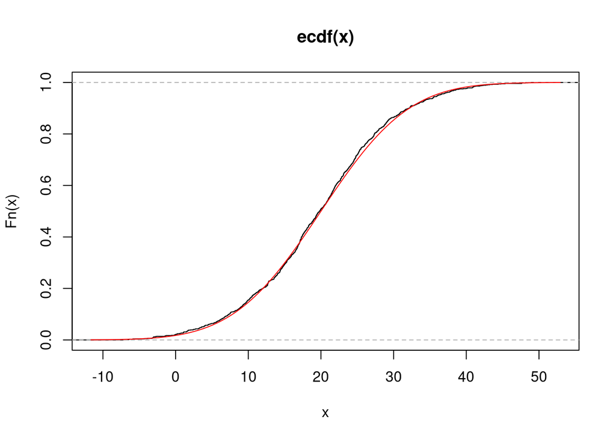

```r
n=10; mu=2; sig=3
N=1000; dist=numeric(N)
for (i in 1:N){
  dist[i]=sum(rnorm(n, mu, sig))
}
plot.ecdf(dist)
curve(pnorm(x, n*mu, sqrt(n)*sig), add=TRUE, col="red")
```

Instead of plotting the empirical cumulative distribution function and the guessed cumulative distribution function in the same graph, one sometimes draws a so-called qq plot instead. Such a plot draws the (generalized) inverse functions of the CDF and the ECDF against each other, at values determined from the given data set. If the CDF is guessed correctly, then the points of the qq plot will approach the diagonal with increasing sample size.

This can be studied in the following simulation.

```r
library(car)
```

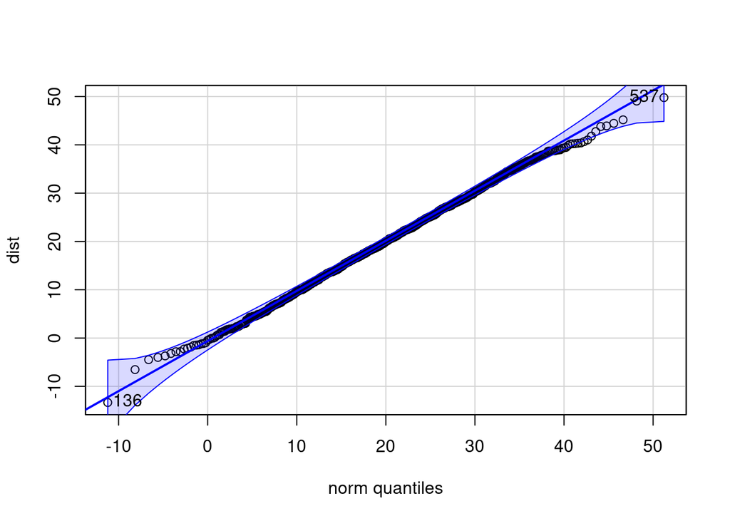

```
## [1] 136 537
```

```r
n=10; mu=2; sig=3
N=1000; dist=numeric(N)
for (i in 1:N){
  dist[i]=sum(rnorm(n, mu, sig))
}
qqPlot(dist, dist="norm", mean=n*mu, sd=sqrt(n)*sig)
```

As a rule of thumb, your guess will be consistent with the given data if at least 95% of the data points will lie in the shaded region.

## 4.2 Sums for variables with finite positive variance

Now consider the above problem for an arbitrary distribution with finite expectation $\mu$ and finite positive variance $\sigma^2$. In that case, another very surprising phenomenon arises: For sufficiently large $n$, we still have approximately

$$S_n \approx a_n + b_n X \ ,$$

with $a_n=n\mu$ and $b_n=\sqrt{n\sigma^2}$, and with $X$ a standard normally distributed random variable. Thus the very complicated sum $S_n$, which might be a discrete or a continuous random variable, is in fact well approximated by a scaled and translated version of a standard normally distributed random variable $X$. For the normal approximation, the only information of the underlying distribution you need to know is its expectation and its variance! The above phenomenon motivates to call the Gauss distributions normal distributions.

Note that this phenomenon is compatible with the law of large numbers, as the arithmetic mean $\overline{X}_n=\frac{1}{n}S_n$ has expectation $\mu$ and variance $\sigma^2/n$ and is approximately normally distributed for large $n$. Thus the arithmetic means concentrates about $\mu$ with increasing $n$. In particular, the arithmetic mean is a very good estimator of the expectation of the underlying distribution.

The normal approximation phenomenon is expressed in several mathematical statements, notably in the central limit theorem. Under the above assumptions, a precise formulation is

$$\mathbb P\left[\frac{S_n-a_n}{b_n}\le t\right] \to \mathbb P[X\le t]
\qquad (n\to\infty) \ ,$$

uniformly in $t\in \mathbb R$. In fact, a normal approximation might still hold if identical distribution or independence are slightly violated. This is a common situation when modelling experiments.

Let us observe this phenomenon in a simulation. Assume $X_1, \ldots, X_n$ are independent and distributed as $X_i \sim Poi(\lambda)$, then each $X_i$ has $\mathbb{E}[X]=\lambda$ and $\mathbb{V}[X]=\lambda$, so their sum $S_n$ has $\mathbb{E}[S_n]=n\lambda$ and $\mathbb{V}[S_n]=n\lambda$. We can thus write

$$S_n= a_n + b_n X \ .$$
where $a_n=n\lambda$ and $b_n=\sqrt{n\lambda}$, with $X$ an $N(0,1)$-distributed random variable. Expecting a normal distribution of $S_n$, we can plug in the values for $\mathbb{E}[S_n]$ and $\mathbb{V}[S_n]$ to get $S_n \sim \mathcal{N}[\mu=n\lambda,\sigma^2=n\lambda]$ Thus the seemingly complicated random variable $S_n$ is in fact a scaled and translated version of a standard normally distributed random variable $X$.

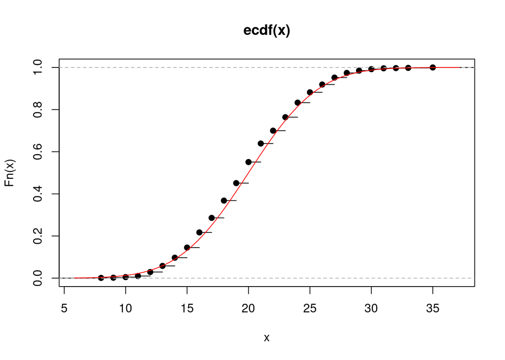

```r
n=10; mu=2; sig=3
N=1000; dist=numeric(N)
for (i in 1:N){
  dist[i]=sum(rpois(n=n, lambda=mu))
}
plot.ecdf(dist)
curve(pnorm(x, n*mu, sqrt(n*mu)), add=TRUE, col="red")
```

Here is a qq plot.

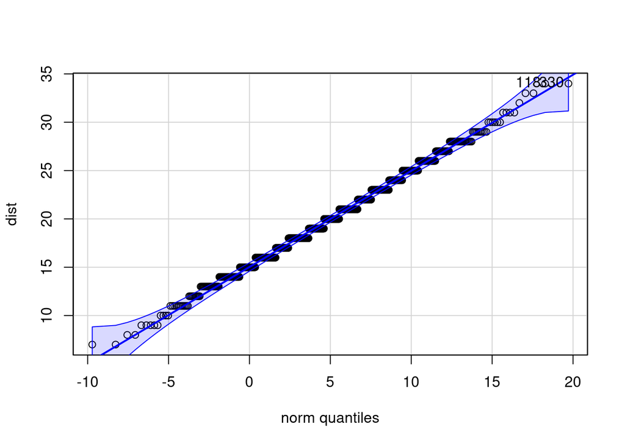

```
## [1] 118 330
```

```r
library(car)
n=10; mu=2; sig=3
N=1000; dist=numeric(N)
for (i in 1:N){
  dist[i]=sum(rpois(n=n, lambda=mu))
}
qqPlot(dist, dist="norm", mean=n*p, sd=sqrt(n*mu))
```

The normal approximation phenomenon also explains why the normal distributions appear frequently in experiments: Often a random mechanism might be viewed as arising from a number of small additive random effects. In that case a normal distribution will be a good approximate description.

## 4.3 Beyond the normal distribution stability class

We have discussed that the normal distribution class has a certain stability property: It is stable under taking sums. Moreover, a normal approximation holds for the sum of random variables having finite expectation and positive finite variance. One might now consider distributions which do not have an expectation or whose expectation exists but whose variance is infinite. Loosely spoken, for such distributions extreme values may occur quite often. An example is the class of so-called Cauchy distributions, which do not have an expectation. The class of Cauchy distributions is again stable under taking sums, and a Cauchy approximation holds for a large class of distributions that do not have an expectation. In general, stable distributions have been classified, and associated approximation results have been derived. In applications, the most important stable class is normal distributions.

# 5 Maximum of random variables and the Gumbel distribution

Let $X_1, \ldots, X_n$ be independent identically distributed random variables. You might be interested to study their maximum

$$M_n=\max\{X_1, \ldots, X_n\} \ .$$

For example, this quantity arises if you are interested in temperature records over $n$ years or the alignment scores of DNA sequences. In order to judge whether an alignment score is high and thus potentially biologically relevant, you might compare it to alignment scores in a random alignment. In particular, the maximal alignment score in a random model is then an important quantity.

However the question arises whether the complicated random variable $M_n$ has a simple approximation for large $n$. Can we approximate

$$M_n \approx a_n + b_n X \ ,$$

in the sense of distribution functions, for numbers $a_n$ and positive numbers $b_n$ and some “simple” random variable $X$?

For example, let us assume that $X_1, \ldots, X_n$ are independent $Exp(\lambda)$-distributed. Choosing $a_n=(\log n)/\lambda$ and $b_n=1/\lambda$, we observe for the centralized maximum $(M_n-a_n)/b_n$ that

$$\begin{align}
\mathbb P \left[\frac{M_n-a_n}{b_n}\le t\right]&= \mathbb P[X_1\le
a_n+b_nt ]^n \\
&=\left(1-e^{-\lambda(a_n+b_nt)}\right)^n \\
&=\left(1-\frac{e^{- t}}{n}\right)^n \\
& \to \exp(-e^{- t}) \qquad (n\to\infty) \ .
\end{align}$$

In this case, the limiting distribution of the centralized maximum is the so-called standard Gumbel distribution $G(0,1)$. Thus $X$ in the above approximation can be chosen as a standard Gumbel-distributed random variable.

The Gumbel distribution is one of the so-called *generalized extreme value distributions*, or GEV distributions, which hold a special place in statistics. They are the central object of study within the field of *extreme value theory*. They are used to model “extreme values”. The Gumbel distribution is arguably the most important GEV.

We have argued in the micro-primer on stochastic calculus that the Gumbel distribution often approximates the distribution of the maximum of a large number of independent identically distributed random variables. This holds as soon as the probability of large or small values of the individual random variables decays at least exponentially fast.

A random variable $X$ that is distributed as $G(a,b)$ has the CDF

$$\begin{align}
F_X(t)=\exp(-e^{-(t-a)/b}) \qquad (t\ge 0) \ ,
\end{align}$$

A PDF $f$ is obtained by differentiation of $F_X(t)=\int_{-\infty}^t f(x) dx$. We obtain

$$\begin{align}
f_{a,b}(x) &= \frac{1}{b} exp(-z+e^{-z}),\quad z =
\frac{x-a}{b},\quad -\infty < z < \infty. \\
\end{align}$$

The expectation and variance of an RV that is Gumbel-distributed with parameters $a$ and $b$ are

$$\begin{align}
\mathbb{E}[X]&= a + b\gamma\\
\mathbb{V}[X]&= \frac{b^2\pi^2}{6}
\end{align}$$
where $\gamma := \lim_{n\to\infty}(\sum_{k=1}^n\frac{1}{k}-log_e(n)) \approx 0.5772$ is the Euler-Mascheroni constant. The Gumbel distribution is not part of the base R environment. So in order to use it just like any other distribution in R, we need to load the `ordinal` package. You may need to install the package first (try loading it into R once in order to know whether it is installed or not). You can check out how to install R packages in the previous part of the course `Introduction_to_R`. In R, the Gumbel distribution can be plotted as follows:

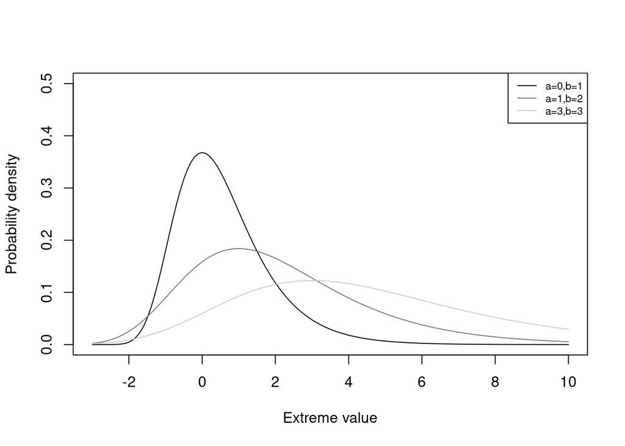

```r
library(ordinal) # the package that contains the Gumbel distribution
x_values <- seq(-3, 10, 0.1)
plot(x_values, dgumbel(x=x_values, location = 0, scale = 1), col='black', type = 'l', ylim = c(0,0.5),
     xlab = "Extreme value", ylab = 'Probability density')
lines(x_values, dgumbel(x=x_values, location = 1, scale = 2), col='#777777', lty=1)
lines(x_values, dgumbel(x=x_values, location = 3, scale = 3), col='#CCCCCC', lty=1)
# Add a legend
legend('topright', legend = c("a=0,b=1", "a=1,b=2", "a=3,b=3"),
       col = c("black", "#777777", "#CCCCCC"), lty = 1, cex = 0.7)
```

In the case of the standard Gumbel distribution ($a = 0$, $b =1$), the distribution reduces to $f(x) = exp(e^{-x})$.

Here is a plot of the cumulative distribution function and of the probability density function of the Gumbel distribution in *R*.

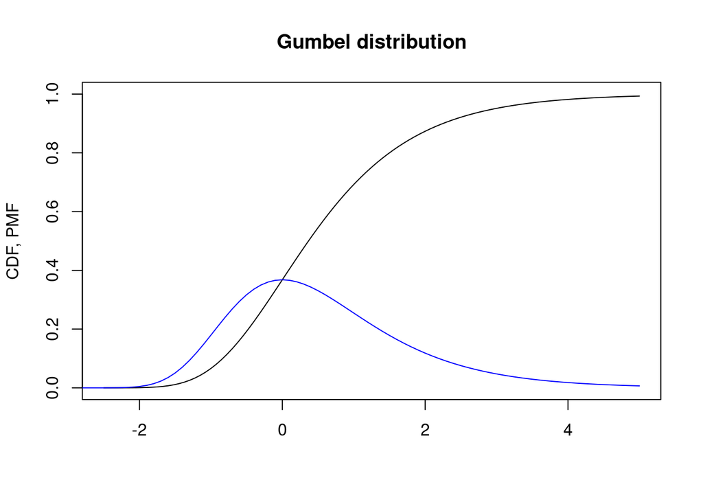

```r
library(ordinal)
a=0; b=1;
cdf=function(x) pgumbel(x, location = a, scale = 1/b)
plot(cdf, -2.5,5, ylim=c(0,1), xlab="", ylab="CDF, PMF", main="Gumbel distribution")
pmf=function(x) dgumbel(x, location = a, scale = 1/b)
curve(pmf(x), -5,5, add=TRUE, col="blue")
```

Let us check numerically the claimed approximation property. Instead of comparing the cumulative distribution function of the data and of the standard Gumbel distribution, we use a qq plot. This corresponds to comparing the (generalized) inverse functions of the two distributions.

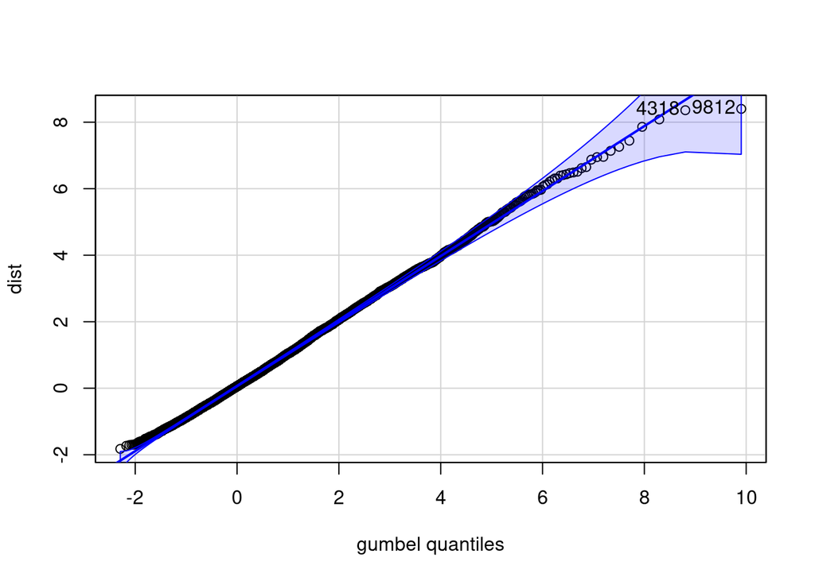

```
## [1] 9812 4318
```

```r
lambda=2; n=10
N=10000; Mn=numeric(N)
for (i in 1:N) Mn[i]=max(rexp(n,rate=lambda))
an=log(n)/lambda; bn=1/lambda
dist=(Mn-an)/bn
library(car)
qqPlot(dist, dist="gumbel", location=0, scale=1)
```

We see that the data points are close to the diagonal, which is compatible with the statement that the empirical distribution of the data is close to the standard Gumbel distribution. Note that the above approximation seems excellent, also for small numbers $n$!

Let us consider an even more concrete example. Consider some simulated data representing the amount of precipitation collected by a weather station once per day for several years.

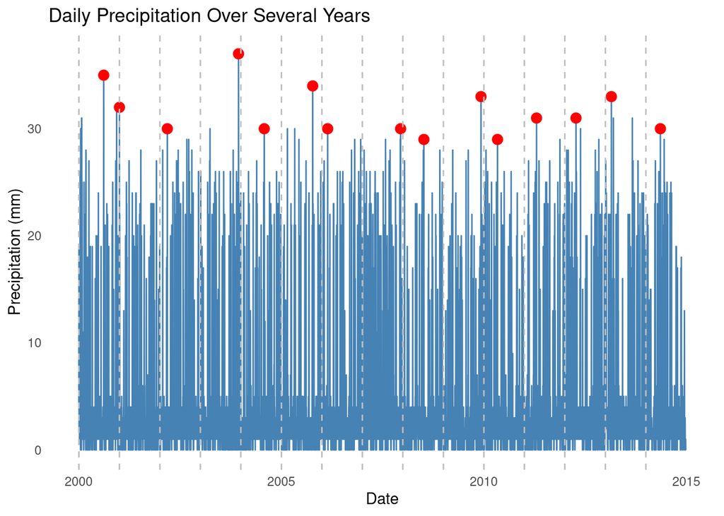

In the figure above, we have plotted the precipitation at each day, where the maximum precipitation for each year is highlighted in red. The dashed vertical lines indicate the beginning of each year. The data is generated for 15 years, with 365 days per year.

We can now ask what the distribution of these highlighted extreme values might look like. That is exactly what the GEV distributions are used for. The *extreme value theorem* (which is also called *Fisher-Tippett-Gnedenko* theorem and should not be confused with the extreme value theorem you may know from calculus), states that the distribution of the maximum of a large number of independent and identically distributed RVs follows approximately a GEV distribution.

It is in some way similar to the central limit theorem, which states that the sum of a large number of independent and identically distributed RVs with finite variance should follow a stable distribution, usually the normal distribution, independently of the distribution of the RVs themselves. In contrast, the extreme value theorem merely states that **if** the distribution of a normalized maximum converges, then the limit must be a GEV distribution.

The figure below shows a histograms of the maximum annual rainfall in comparison to the best fitting Gumbel distribution. You see that, for 100,000 simulated years, a Gumbel distribution is a very good description.

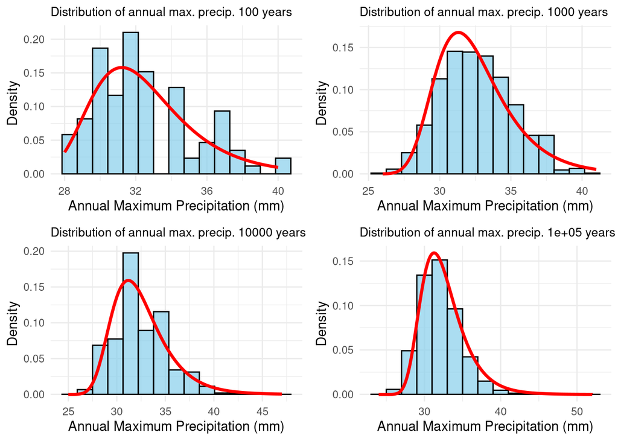

Other fields and examples where the Gumbel distribution is used include:

- The maximum level of a river in a year (flood risk assessment)
- The maximum wind speed in a year (storm risk assessment)
- The maximum stock price in a year (financial risk assessment)
- The maximum earthquake magnitude in a year (seismic risk assessment)
- The maximum number of customers in a queue in a year (queuing theory)
- The maximum number of calls in a call center in a year (telecommunications)
- The maximum number of errors in a software system in a year (software engineering)
- The maximum number of patients in a hospital in a year (healthcare management)